# HW_8

Jillian Sarazen

3/30/2020

Organizing Code With Structured Programming

1. Use the code that you worked on in Homework #7 (creating fake data sets) , and re-organize it following the principles of structured programming. Do all the work in a single chunk in your R markdown file, just as if you were writing a single R script. Start with all of your annotated functions, preliminary calls, and global variables. The program body should be only a few lines of code that call the appropriate functions and run them in the correct order. Make sure that the output from one function serves as the input to the next. You can either daisy-chain the functions or write separate lines of code to hold elements in temporary variables and pass the along.

```r
# ---------------------------------------------
# Structured programming HW
# 30 Mar 2020
# JCS
# ---------------------------------------------

# Load libraries --------------------------------
library(ggplot2)


# ---------------------------------------------
# FUNCTION get_data2
# description: create a data frame with two treatment groups
# inputs: none
# outputs: data frame
###############################################
get_data2 <- function(n_group = 2,
                      n_names = c("WCB1", "WCB2"),
                      n_size = c(14,15),
                      n_mean = c(23.79,45.39),
                      n_sd = c(13.57,25.24)) {
  t_group <- rep(n_names,n_size)
  id <- 1:(sum(n_size))
  res_var <- c(rnorm(n=n_size[1],mean=n_mean[1],sd=n_sd[1]),
             rnorm(n=n_size[2],mean=n_mean[2],sd=n_sd[2]))
  fake_data <- data.frame(id,t_group,res_var)

return(fake_data)

} # end of get_data
#----------------------------------------------
results <- get_data2() ### name this so that I can use in next function


# ---------------------------------------------
# FUNCTION ano_calc
# description: calculates ANOVA model
# inputs: data frame with 2 treatment groups
# outputs: summary of ANOVA model
###############################################
ano_calc <- function(fake_data=results) {

  ano_model <- aov(res_var~t_group,data=fake_data)

return(summary(ano_model))

} # end of ano_calc
#----------------------------------------------
ano_calc()
```

```
##             Df Sum Sq Mean Sq F value Pr(>F)
## t_group      1   4724    4724   11.99 0.0018 **
## Residuals   27  10635     394
## ---
## Signif. codes:  0 '***' 0.001 '**' 0.01 '*' 0.05 '.' 0.1 ' ' 1
```

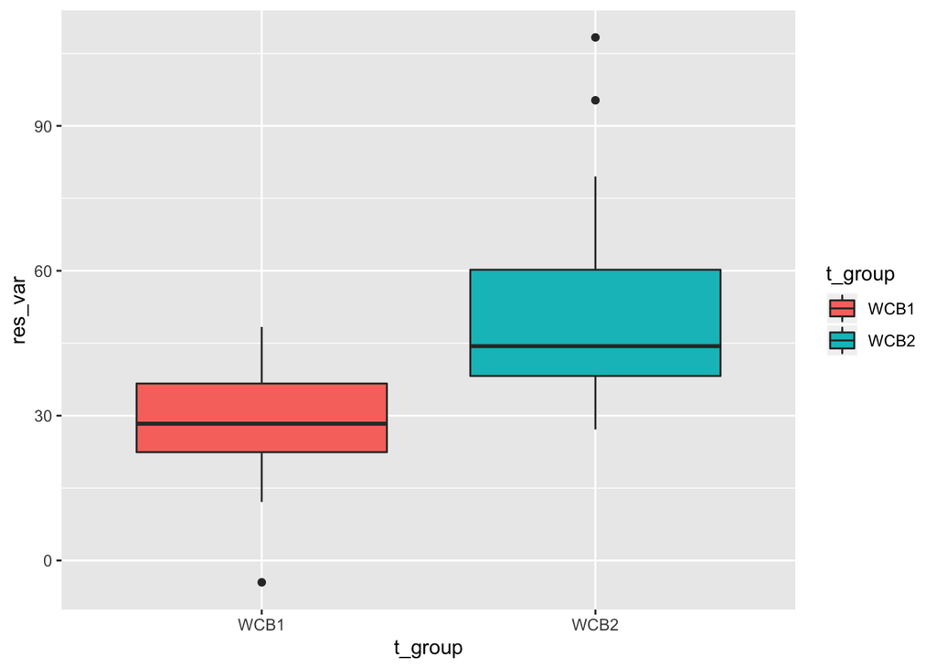

```r
# ---------------------------------------------
# FUNCTION plot_results
# description: plots boxplot
# inputs: dataframe
# outputs: boxplot
###############################################
plot_results <- function(fake_data=results) {

  ano_plot <- ggplot(data=fake_data,
                   aes(x=t_group, # aes=specify asthetics
                       y=res_var,
                       fill=t_group)) +# fill to specify a grouping variable
                      geom_boxplot()

return(ano_plot)

} # end of plot_results
#----------------------------------------------
plot_results()
```

Now running the functions on their own

```r
get_data2() # runs get_data2 function, with the defaults
```

```
##    id t_group    res_var
## 1   1    WCB1  19.944030
## 2   2    WCB1  45.095308
## 3   3    WCB1  15.917107
## 4   4    WCB1  12.261561
## 5   5    WCB1  10.503802
## 6   6    WCB1  23.960786
## 7   7    WCB1  37.146655
## 8   8    WCB1  54.128362
## 9   9    WCB1  19.377359
## 10 10    WCB1   5.989852
## 11 11    WCB1  33.038760
## 12 12    WCB1   7.948378
## 13 13    WCB1  13.328893
## 14 14    WCB1   7.296302
## 15 15    WCB2  48.715066
## 16 16    WCB2  47.862356
## 17 17    WCB2 -12.043264
## 18 18    WCB2  26.496696
## 19 19    WCB2  20.338172
## 20 20    WCB2 -14.967563
## 21 21    WCB2  30.296918
## 22 22    WCB2  45.336779
## 23 23    WCB2  52.375611
## 24 24    WCB2  45.883129
## 25 25    WCB2  56.767122
## 26 26    WCB2  35.543945
## 27 27    WCB2  29.395919
## 28 28    WCB2  84.319435
## 29 29    WCB2  -8.939864
```

```r
ano_calc() # runs ano_calc function, ANOVA model
```

```
##             Df Sum Sq Mean Sq F value Pr(>F)
## t_group      1   4724    4724   11.99 0.0018 **
## Residuals   27  10635     394
## ---
## Signif. codes:  0 '***' 0.001 '**' 0.01 '*' 0.05 '.' 0.1 ' ' 1
```

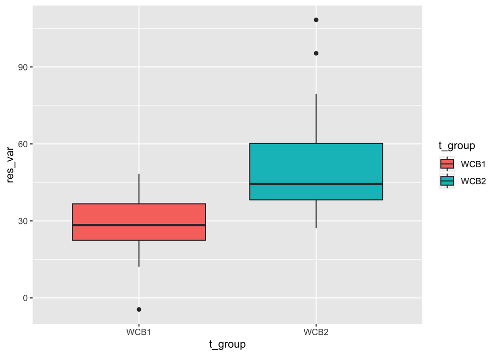

```r
plot_results() # runs plot_results function
```

2. Once your code is up and working, modify your program do something else: record a new summary variable, code a new statistical analysis, or create a different set of random variables or output graph. Do not rewrite any of your existing functions. Instead, copy them, rename them, and then modify them to do new things. Once your new functions are written, add some more lines of program code, calling a mixture of your previous functions and your new functions to get te job done.

```r
# keeping get_data the same as above
# ---------------------------------------------
# FUNCTION get_data
# description: create a data frame with two treatment groups
# inputs: none
# outputs: data frame
###############################################
get_data2 <- function(n_group = 2,
                      n_names = c("WCB1", "WCB2"),
                      n_size = c(14,15),
                      n_mean = c(23.79,45.39),
                      n_sd = c(13.57,25.24)) {
  t_group <- rep(n_names,n_size)
  id <- 1:(sum(n_size))
  res_var <- c(rnorm(n=n_size[1],mean=n_mean[1],sd=n_sd[1]),
             rnorm(n=n_size[2],mean=n_mean[2],sd=n_sd[2]))
  df <- data.frame(id,t_group,res_var)

return(df)

} # end of get_data2
#----------------------------------------------
results <- get_data2()


# changing the output for the ANOVA model to pull out P value
# ---------------------------------------------
# FUNCTION ano_calc2
# description: calculates ANOVA model
# inputs: data frame with 2 treatment groups
# outputs: ANOVA model
###############################################
ano_calc <- function(df=results) {

  ano_model <- aov(res_var~t_group,data=df)
  z <- summary(ano_model) # save as a vector
  unlist(z) # unlist the output of ANOVA model
  ano_sumvec <- c(unlist(z)[7],unlist(z)[9]) # make a vector with the F stat and P value

return(ano_sumvec)

} # end of ano_calc
#----------------------------------------------
ano_calc()
```

```
##     F value1      Pr(>F)1
## 1.822961e+01 2.161478e-04
```

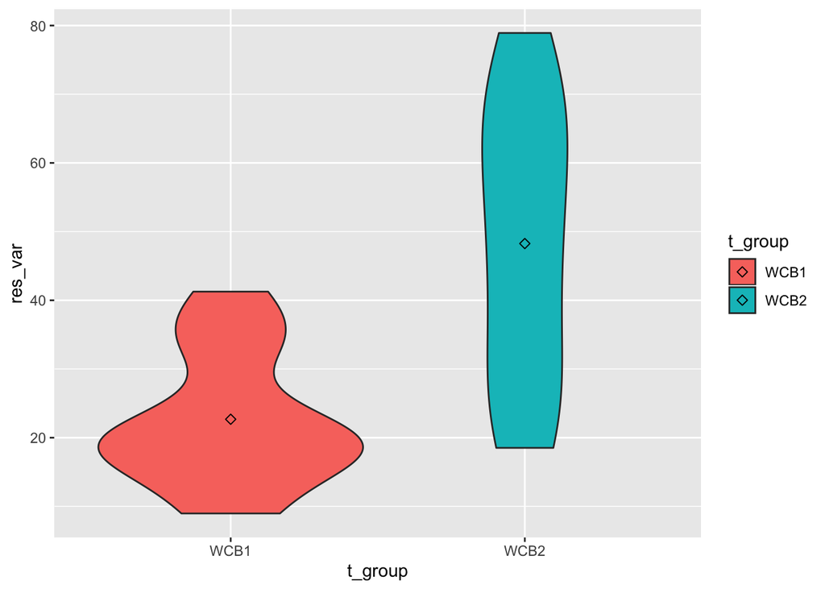

```r
# ---------------------------------------------
# FUNCTION plot_results2
# description: plots violin plot
# inputs: dataframe
# outputs: violin plot
###############################################
plot_results2 <- function(df=results) {


ano_plot2 <- ggplot(data=df,
                   aes(x=t_group, # aes=specify asthetics
                       y=res_var,
                       fill=t_group)) + # fill to specify a grouping variable
                      geom_violin()

p <- ano_plot2 + stat_summary(fun.y=mean, geom="point", shape=23, size=2)

return(p)

} # end of plot_results
#----------------------------------------------
plot_results2()
```